# Final Project: Analysis 1 by Louis Harris

# Analysis #1 - Sentiment Analysis vs. Quantitative Review Scores

The purpose of this analysis is to observe the relationship between the sentiment analysis of qualitative summaries for certain products, and their quantitative review scores.

Sentiment values were collected using the bing sentiment lexicon. NRC was originally considered, but the calculations resulted in fatal errors in RStudio and loss of progress.

## Step 1: Loading Libraries

Here, libraries that are needed for data importation, analysis, and presentation are loaded.

```r
#####################################
###      LIBRARY INFORMATION      ###
#####################################
#for loading the cleaned data
library(data.table)
#text mining library, if needed
library(tm)
#multi-function sentiment analysis library (includes lexicons and NRC sentiment analysis)
library(syuzhet)
#for creating visual analytic graphs
library(ggplot2)
#expanded ggplot functionality
library(ggpubr)
```

## Step 2: Preparing Data for Analysis

During this step, the data set is loaded in and assigned to a variable. The required data for the analysis is taken from the original set and placed into a separate data set.

In this case, the information that is needed is index value, the review summary text, and the actual review score.

```r
################################
###      DATA PREP WORK      ###
################################
#import cleaned dataset
foods <- fread(file = "C:/Users/louis/Desktop/Text Mining Project/Text Mining Project/Data/finefoods.csv")

###BASIC PREP
#assign dataset to dataframe
reviewSummary <- as.data.frame(foods$`review/summary`)
#convert summary text to vector to prepare for sentiment analysis
review1 <- as.character(reviewText$`review/summary`)

###SENTIMENT ANALYSIS PREP
#create dataframe with only the columns that will be analysed
reviewText <- foods[, c("V1","review/summary","review/score")]
```

Provided are examples of what each set looks like.

```r
head(reviewSummary)
```

|  | foods$`review/summary` |
| --- | --- |
| 1 | Good Quality Dog Food |
| 2 | Not as Advertised |
| 3 | ""Delight"" says it all |
| 4 | Cough Medicine |
| 5 | Great taffy |
| 6 | Nice Taffy |

```r
head(review1)
```

```
[1] "Good Quality Dog Food"        "Not as Advertised"            " \"\"Delight\"\" says it all"
[4] "Cough Medicine"               "Great taffy"                  "Nice Taffy"
```

```r
head(reviewText)
```

| V1 | review/summary | review/score |
| --- | --- | --- |
| 0 | Good Quality Dog Food | 5 |
| 1 | Not as Advertised | 1 |
| 2 | ""Delight"" says it all | 4 |
| 3 | Cough Medicine | 2 |
| 4 | Great taffy | 5 |
| 5 | Nice Taffy | 4 |

## Step 3a: Analysis

The originally planned NRC analysis, however, the original data source proved to be too large and command execution would result in RStudio crashing.  
Both the NRC and bing sentiment analyses were ran with the *syuzhet* library.

```r
###NRC SENTIMENT ANALYSIS###
#nrc sentiment analysis - ran into issues with commands crashing rstudio, so this part was not included
#assign sentiment analysis results to variable
x <- get_nrc_sentiment(review1)

#filter out only positive and negative sentiments and assign to a seperate variable
posneg <- x[, c("positive","negative")]
review <- cbind(reviewText, posneg)

#create dataframe with index value, summary text, positive and negative values, the overall sentiment value, and the actual review score
totalSent <- as.data.frame(posneg$positive - posneg$negative)
reviewProperOrder <- cbind(foods$V1, foods$`review/summary`, posneg, totalSent, foods$`review/score`)
```

This is what the NRC sentiment analysis table would have looked like if it were completed.

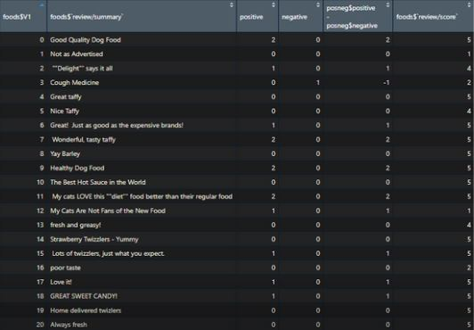

Since the NRC sentiment analysis didn’t work out, the bing lexixon was used for sentiment analysis.

```r
###BING SENTIMENT ANALYSIS###
#similar dataframe, but using the "bing" lexicon
bing <- as.data.frame(get_sentiment(review1, method = "bing"))
reviewBing <- cbind(foods$V1, foods$`review/summary`, bing, foods$`review/score`)

#rename columns for simplicity
names(reviewBing) [1] <- 'Index'
names(reviewBing) [2] <- 'Summary'
names(reviewBing) [3] <- 'Bing'
names(reviewBing) [4] <- 'Review'

reviewBing
```

| Index | Summary | Bing | Review |
| --- | --- | --- | --- |
| 0 | Good Quality Dog Food | 1 | 5 |
| 1 | Not as Advertised | 0 | 1 |
| 2 | ""Delight"" says it all | 1 | 4 |
| 3 | Cough Medicine | 0 | 2 |
| 4 | Great taffy | 1 | 5 |
| 5 | Nice Taffy | 1 | 4 |
| 6 | Great! Just as good as the expensive brands! | 1 | 5 |
| 7 | Wonderful, tasty taffy | 1 | 5 |
| 8 | Yay Barley | 1 | 5 |
| 9 | Healthy Dog Food | 1 | 5 |

[output cut: 990 more lines]

## Step 3b: Visual Analysis w/ Graphics

To get a basic grasp on the data that has been collected we begin with some basic information.

```r
#Frequency table for bing sentiment analysis
table(reviewBing$Bing)
```

```
    -6     -5     -4     -3     -2     -1      0      1      2      3      4      5      6      7
     1      4     14    281   3929  47758 192535 275368  43728   4403    397     32      3      1
```

```r
#mean bing sentiment analysis value
mean(reviewBing$Bing)
```

```
[1] 0.5651557
```

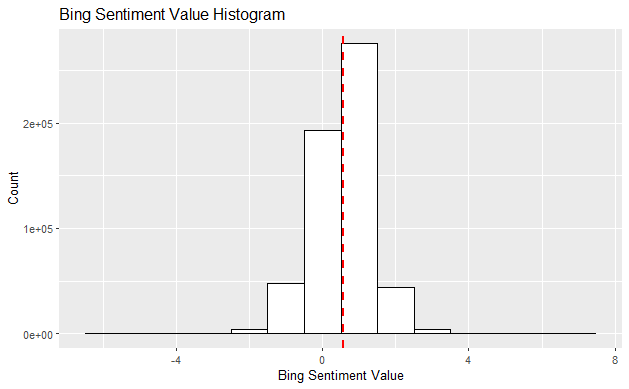

```r
#histogram for bing sentiment values/ with mean value as a red, dashed, vertical line
ggplot(reviewBing, aes(x=Bing)) +
  geom_histogram(binwidth = 1, center = -6, colour="black", fill="white") +
  ggtitle("Bing Sentiment Value Histogram") +
  xlab("Bing Sentiment Value") +
  ylab("Count") +
  geom_vline(aes(xintercept=mean(Bing)),
             color="red", linetype="dashed", size=1)
```

Just off of these three basic analytic functions, we can assume based on the sentiment analysis results that **there will be a large number of positive reviews**. The frequency table and histogram show how to quantity leans towards the positive side heavily. And the **positive mean value** shows that **overall, the reviews are positive.**

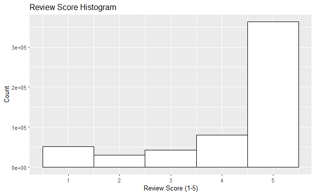

```r
#histogram of actual quantitative reviews
ggplot(reviewBing, aes(x=Review)) +
  geom_histogram(binwidth = 1, colour="black", fill="white") +
  ggtitle("Review Score Histogram") +
  xlab("Review Score (1-5)") +
  ylab("Count")
```

This histogram of the actual reviews collected confirms the previous assumption that was made using sentiment analysis results. Since the quantitative scores and qualitative summaries support one another, **we can suggest a potential relationship between the two variables**.

**To test this further, we run a Pearson correlation test to see if this is true. Also, to make sure that the function doesn’t have any inherent flaws, I’ve ran it with the variables in both potential orders.**

```r
#Pearson correlation test - ran with both variable orders in the off chance of a function error
cor.test(reviewBing$Bing, reviewBing$Review , method = "pearson")
```

```
    Pearson's product-moment correlation

data:  reviewBing$Bing and reviewBing$Review
t = 336.92, df = 568452, p-value < 2.2e-16
alternative hypothesis: true correlation is not equal to 0
95 percent confidence interval:
 0.4058168 0.4101506
sample estimates:
     cor
0.407986
```

```r
cor.test(reviewBing$Review, reviewBing$Bing, method = "pearson")
```

```
    Pearson's product-moment correlation

data:  reviewBing$Review and reviewBing$Bing
t = 336.92, df = 568452, p-value < 2.2e-16
alternative hypothesis: true correlation is not equal to 0
95 percent confidence interval:
 0.4058168 0.4101506
sample estimates:
     cor
0.407986
```

In both cases, **the p-value is much lower than 0.05**, so we can **reject** the **null hypothesis** and confirm that the **sentiment analysis values and the quantitative scores relate to one another**.

## Step 4: Conclusions

### The sentiment analysis results pointed to the reviews being majority positive, this was supported by the actual quantitative review scores. Since both variables matched one another in their predictions, a Pearson correlation test was ran, which confirmed that they had a statistically signification relationship.

### With all of these points, we can confirm that in this data set, when using the bing lexicon, **the sentiment analysis of the summary text aligned with the quantitative reviews.**

save.image(file = “/.RData2”, version = NULL, ascii = FALSE, compress = !ascii, safe = TRUE)